# Marine Trade in Africa

Task from Kyra

Roman Rakov

11/24

```r
library(sf)
library(tidyr)
library(dplyr)
library(ggplot2)
library(rnaturalearth)
library(stargazer)
library(plm)
library(pdynmc)
library(purrr)
library(broom)
library(lmtest)
library(baggr)
```

```r
# setwd("M:\Student\Rakov\Tasks Kyra")

# Load the RDS file
dist_df <- readRDS("cities_close_to_ports.rds")
city_df <- readRDS("city_lights_monthly.rds")
port_df <- readRDS("port_lights_monthly.rds")
etno_df <- readRDS("ethnic_geo_info_recent.rds")
```

**Test**: removing city duplicates

```r
# Assuming dist_df is your data frame
dist_df <- dist_df %>%
  group_by(city_id) %>%
  filter(distance_to_port_km == min(distance_to_port_km)) %>%
  ungroup()
```

## Map Centroids to Countries

**Issue**: some cities in the dataset are outside the African map. I delete them:

```r
# Find most east cities:
# most_right_point <- dist_df %>%
#   mutate(x_coord = st_coordinates(geom)[, 1]) %>%
#   slice_max(order_by = x_coord, n = 5)
#
# print(most_right_point)

# Delete cities and Convert geometries to points
temp_df <- dist_df %>%
  filter(!city_id %in% c(22453, 22451, 22452, 22450)) %>%
  mutate(geom = st_centroid(geom))
```

Match country name based on its cities location:

```r
africa <- ne_countries(scale = "medium", continent = "Africa", returnclass = "sf")

# Reproject the 'dist_sf' geometry
city_point <- st_transform(temp_df, st_crs(africa))

# Convert 'city_point' to an sf object
city_point_sf <- st_sf(geometry = city_point)

# Perform the spatial join to add country names
matched <- st_join(city_point_sf, africa["sovereignt"]) %>%
  rename(name = sovereignt)

# Identify points with NA after spatial join
na_points <- matched[is.na(matched$name), ]

# Find the nearest country for each NA point
nearest_country <- st_nearest_feature(na_points, africa)

# Assign the name of the nearest country to these points
na_points$name <- africa$name[nearest_country]

# Combine the updated NA points back with the original matched dataset
matched$name[is.na(matched$name)] <- na_points$name
```

## Running a regression

First, prepare the data:

```r
data <- city_df %>%
  left_join(matched %>%
  select(city_id, port_id, distance_to_port_km, port_city, closest_port, name), by = "city_id") %>%
  drop_na()
# Combine year and month into a Date column
data <- data[, c("city_id","year","month","light","port_city", "name", "distance_to_port_km")] %>%
  mutate(date = as.Date(paste(year, month, "01", sep = "-")))
```

**Idea**: create bins, pool everything within each bin. Ports and cities. Start with just one country.

Get the data ready:

```r
country <- "Liberia"

merged_data <- data %>%
  filter(name == country) %>%
  mutate(
    distance_bin = cut(
      distance_to_port_km,
      breaks = c(0, 10, 50, 100, 150, Inf),
      labels = c("0-10", "10-50", "50-100", "100-150", "150-200"),
      right = FALSE
    )
  ) %>%
  group_by(year, month, distance_bin) %>%
  summarise(avg_light_city = mean(light, na.rm = TRUE), .groups = "drop") %>%
  full_join(
    port_df %>%
      filter(country == country) %>%
      group_by(year, month) %>%
      summarise(avg_light_port = mean(light, na.rm = TRUE), .groups = "drop"),
    by = c("year", "month")
  )
```

Important thing that was not obvious to me: regression coefficients are not partial correlations!

[Multiple regression or partial correlation coefficient? And relations between the two - Cross Validated](https://stats.stackexchange.com/questions/76815/multiple-regression-or-partial-correlation-coefficient-and-relations-between-th)

-> Need to standardize them in order to get correlation coefficients.

Run this code if any one country is of interest. Note that it does not run through if a country does not have all the bins you specified:

```r
# Run regression for each distance bin
run_regression <- function(data, distance_bin) {
  # Filter the data for the current distance_bin
  subset_data <- data %>% filter(distance_bin == !!distance_bin)

  subset_data$avg_light_city <- scale(subset_data$avg_light_city)
  subset_data$avg_light_port <- scale(subset_data$avg_light_port)
  # Fit the regression model
  model <- lm(avg_light_city ~ avg_light_port, data = subset_data)
  return(model)}

# Create lists
distance_bins <- c("0-10", "10-50", "50-100", "100-150", "150-200")
models <- list()

# Run regression for each bin and store the model results
for (bin in distance_bins) {
  models[[bin]] <- run_regression(merged_data, bin)}
```

```
Error in lm.fit(x, y, offset = offset, singular.ok = singular.ok, ...) :
  0 (non-NA) cases
```

This code also runs for countries with some bins missing:

```r
# Run regression for each distance bin
run_regression <- function(data, distance_bin) {
  # Filter the data for the current distance_bin
  subset_data <- data %>% filter(distance_bin == !!distance_bin)

  # Check if the subset has data
  if (nrow(subset_data) > 0) {
    # Remove NA values for the relevant columns
    subset_data <- subset_data %>%
      drop_na(avg_light_city, avg_light_port)

    # Run the regression model if there are valid rows
    # Standardize the variables
    subset_data$avg_light_city <- scale(subset_data$avg_light_city)
    subset_data$avg_light_port <- scale(subset_data$avg_light_port)
   model <- lm(avg_light_city ~ avg_light_port, data = subset_data)
    return(model)
  } else {
    # Return NULL if no data is present for this bin
    warning(paste("No data available for bin:", distance_bin))
    return(NULL)
  }
}

# List of distance bins
distance_bins <- c("0-10", "10-50", "50-100", "100-150", "150-200")
models <- list()

# Run regression for each bin and store the model results only if the bin is present in the data
for (bin in distance_bins) {
  # Only run the regression if the bin has data in the dataset
  if (bin %in% unique(merged_data$distance_bin)) {
    models[[bin]] <- run_regression(merged_data, bin)
  } else {
    warning(paste("Bin", bin, "is not present in the data"))
  }
}
# Collect the regression coefficients into a data frame (ignoring NULL models)
regression_results <- lapply(models, function(model) {
  if (!is.null(model)) {
    return(coef(model))
  } else {
    return(NULL)
  }
})

# Filter out NULL results from the regression
regression_results <- regression_results[!sapply(regression_results, is.null)]

# Combine the results into a data frame
regression_results_df <- do.call(rbind, regression_results)
colnames(regression_results_df) <- c("Intercept", "Slope")

cat("\n")  # Prints an empty line
```

```r
regression_results_df
```

```
            Intercept     Slope
0-10     2.048738e-16 0.3233721
10-50   -4.910974e-16 0.1536347
100-150 -1.168954e-16 0.3876418
150-200  1.742854e-16 0.3598884
```

## Multiple Regressions at once

Run the models for every country and save the results:

```r
# Get unique list of countries
countries <- unique(data$name)

# Loop over each country
for (country in countries) {
  # Filter data for the specific country
  city_data <- data %>% filter(name == country)
  port_data <- port_df %>% filter(country == country)

  # Categorizing distance into bins
  city_data <- city_data %>%
    mutate(distance_bin = cut(distance_to_port_km,
                        breaks = c(0, 10, 50, 100, 150, Inf),
                        labels = c("0-10", "10-50", "50-100", "100-150", "150-200"),
                              right = FALSE)) # 0 is included in the first bin

  # Calculate average light intensity by year, month, and distance bin
  light_by_bin <- city_data %>%
    group_by(year, month, distance_bin) %>%
    summarise(avg_light_city = mean(light, na.rm = TRUE), .groups = 'drop')

  light_port <- port_data %>%
    group_by(year, month) %>%
    summarise(avg_light_port = mean(light, na.rm = TRUE), .groups = 'drop')

  # Get the final data for regressions
  merged_data <- merge(light_by_bin, light_port, by = c("year", "month"))

  # List of distance bins
  distance_bins <- levels(light_by_bin$distance_bin)

  # Create a list to store the models
  models <- list()

  # Run regression for each bin and store the model results
  for (bin in distance_bins) {
    if (!is.na(bin)) {
      models[[bin]] <- tryCatch(
        {
          subset_data <- merged_data %>% filter(distance_bin == bin)
          subset_data$avg_light_city <- scale(subset_data$avg_light_city)
          subset_data$avg_light_port <- scale(subset_data$avg_light_port)
          lm(avg_light_city ~ avg_light_port, data = subset_data)
        },
        error = function(e) NULL
      )
    }
  }

  # Collect the regression coefficients into a data frame
  regression_results <- lapply(models, function(model) {
    if (!is.null(model)) {
      broom::tidy(model)
    } else {
      NULL
    }
  }) %>%
    bind_rows(.id = "Distance_Bin")

  # Filter for slopes (avg_light_port coefficient)
  regression_results <- regression_results %>%
    filter(term == "avg_light_port") %>%
    mutate(
      Conf_Low = estimate - 1.96 * std.error,
      Conf_High = estimate + 1.96 * std.error
    )

  # Manually set the desired order for distance bins
  regression_results <- regression_results %>%
    mutate(Distance_Bin = factor(Distance_Bin, levels = distance_bins))


  # Create the plot
  plot <- ggplot(regression_results, aes(x = Distance_Bin, y = estimate)) +
    geom_point(size = 3, color = "blue", shape = 16) + # Blue points for estimates
    geom_errorbar(aes(ymin = Conf_Low, ymax = Conf_High), width = 0.2, color = "darkred", linetype = "solid") + # Red error bars
    geom_hline(yintercept = 0, linetype = "dashed", color = "black", size = 0.8) + # Dashed line at y = 0
    labs(
      title = paste("Correlation Coefficients by Distance Bin:", country),
      subtitle = "Correlation estimate between ports and cities",
      x = "Distance Bin (km)",
      y = "Correlation",
      caption = "Note: Error bars represent 95% confidence intervals."
    ) +
    theme_minimal(base_size = 14) +
    theme(
      axis.text.x = element_text(angle = 45, hjust = 1, size = 12),
      axis.text.y = element_text(size = 12),
      axis.title = element_text(face = "bold"),
      plot.title = element_text(face = "bold", size = 16, margin = margin(b = 10)),
      plot.subtitle = element_text(size = 12, margin = margin(b = 10)),
      plot.caption = element_text(hjust = 0, face = "italic")
    ) +
    ylim(-1.0, 1.0)

  # Save the plot to the specified directory
  # output_path <- paste0("/Users/romanrakov/Desktop/ifo Dresden/Kyra/R/Bounds/", country, ".pdf")
  output_path <- paste0("M:/Student/Rakov/Tasks Kyra/Bounds/", country, ".pdf")
  ggsave(output_path, plot = plot, width = 10, height = 6)
}
```

## Fixed Effects vs. Hierarchical Bayesian Models for Pooling Treatment Effects Across Countries

### **1. Fixed Effects Approach**

Treatment effects are assumed to vary by country but are estimated independently and then pooled through a linear model. For country $i$ and unit $j$ at time $t$:

$$Y_{ijt} = \alpha_i + \beta_i \cdot D_{ijt} + X_{ijt}\gamma +
\epsilon_{ijt}$$

Where $Y_{ijt}$ is the outcome of interest (e.g., light intensity), $D_{ijt}$ is the treatment indicator, $\alpha_i$ are country-specific fixed effects (absorbing country-level heterogeneity), $\beta_i$ is the country-specific treatment effect.

To unify the treatment effects across countries, a fixed-effects pooling can be used:

$$\hat{\beta}_{\text{pooled}} = \frac{\sum_i w_i \hat{\beta}_i}{\sum_i
w_i}$$

Where $w_i$ are weights (e.g., inverse-variance weights).

**Key Characteristics**

1. *Independence Across Countries*: Each country’s $\beta_i$ is estimated separately and combined linearly.
2. *No Information Sharing*: Countries with less data are not informed by data-rich countries.
3. *Assumptions*: Assumes no hierarchical structure, and heterogeneity between $\beta_i$ is ignored in pooling.

### **2. Hierarchical Bayesian Model**

Explicitly models variation in treatment effects across countries by treating the country-specific effects $\beta_i$ as drawn from a shared prior distribution:

For country $i$ and unit $j$ at time $t$:
$$Y_{ijt} \sim \mathcal{N}(\mu_{ijt}, \sigma^2)$$
$$\mu_{ijt} = \alpha_i + \beta_i \cdot D_{ijt} + X_{ijt}\gamma$$

The hierarchical structure for $\beta_i$ is:
$$\beta_i \sim \mathcal{N}(\mu_{\beta}, \tau^2)$$
$$\mu_{\beta} \sim \mathcal{N}(\mu_0, \sigma_0^2), \quad \tau^2 \sim
\text{Inverse-Gamma}(a, b)$$

Where $\mu_{\beta}$ is the global (pooled) treatment effect, $\tau^2$ is the between-country variance (heterogeneity in $\beta_i$), $\mu_0, \sigma_0^2$ are hyperparameters for the prior on $\mu_{\beta}$.

Bayesian inference updates the prior beliefs using the observed data, giving posterior distributions for $\beta_i$ and $\mu_{\beta}$:
$$p(\beta_i, \mu_{\beta}, \tau^2 | Y) \propto p(Y | \beta_i) \cdot
p(\beta_i | \mu_{\beta}, \tau^2) \cdot p(\mu_{\beta}, \tau^2)$$

#### Key Characteristics

1. *Partial Pooling*: Information is shared across countries, with $\beta_i$ estimates “shrinking” toward $\mu_{\beta}$ based on the amount of data for each country and the prior.
2. *Quantifies Uncertainty*: Produces posterior distributions, which directly quantify uncertainty in the treatment effect.
3. *Heterogeneity Modeled*: not sure how exactly, though.

| Aspect | Fixed Effects | Hierarchical Bayesian Model |
| --- | --- | --- |
| **Pooling** | Full pooling after separate estimation. | Partial pooling via shared priors. |
| **Heterogeneity** | Ignored in the pooled estimate. | Modeled explicitly ($\tau^2$). |
| **Small Sample Countries** | Estimates are noisy. | Shrinkage improves stability. |
| **Interpretation** | Point estimates. | Posterior distributions. |
| **Assumptions** | Homogeneous treatment effects when pooled. | Heterogeneity modeled probabilistically. |
| **Flexibility** | Rigid, relies on weights. | Flexible, can include complex priors. |

### **Implications for Unified Estimates**

1. **Fixed Effects**: Suitable when heterogeneity across countries is negligible or not of primary interest. Simpler and computationally cheaper but may produce unreliable estimates for countries with sparse data.
2. **Hierarchical Bayesian**: Preferred when heterogeneity matters or data availability varies significantly between countries.

First, let’s run *Fixed Effects*:

```r
# Initialize an empty data frame to store results
final_results <- data.frame()

# Loop over each country
for (country in countries) {
  # Filter data for the specific country
  city_data <- data %>% filter(name == country)
  port_data <- port_df %>% filter(country == country)

  # Categorizing distance into bins
  city_data <- city_data %>%
    mutate(distance_bin = cut(distance_to_port_km,
                              breaks = c(0, 10, 50, 100, 150, Inf),
                              labels = c("0-10", "10-50", "50-100", "100-150", "150+"),
                              right = FALSE)) # 0 is included in the first bin

  # Calculate average light intensity by year, month, and distance bin
  light_by_bin <- city_data %>%
    group_by(year, month, distance_bin) %>%
    summarise(avg_light_city = mean(light, na.rm = TRUE), .groups = 'drop')

  light_port <- port_data %>%
    group_by(year, month) %>%
    summarise(avg_light_port = mean(light, na.rm = TRUE), .groups = 'drop')

  # Merge data
  merged_data <- merge(light_by_bin, light_port, by = c("year", "month"))

  # Run regression for each bin and store the results
  for (bin in levels(merged_data$distance_bin)) {
    if (!is.na(bin)) {
      subset_data <- merged_data %>% filter(distance_bin == bin)
      model <- tryCatch(
        lm(avg_light_city ~ avg_light_port, data = subset_data),
        error = function(e) NULL
      )

      if (!is.null(model)) {
        # Extract point estimate and standard error
        tidy_model <- broom::tidy(model)
        coeff <- tidy_model %>% filter(term == "avg_light_port")

        if (nrow(coeff) > 0) {
          final_results <- rbind(
            final_results,
            data.frame(
              Country = country,
              Distance_Bin = bin,
              Estimate = coeff$estimate,
              Std_Error = coeff$std.error
            )
          )
        }
      }
    }
  }
}

# View final results
# final_results
```

Now, let’s estimate separate effects for each country and run a *Hierarchical Model*:

```r
# Initialize an empty data frame to store results
final_results <- data.frame()

# Loop over each country
for (country in countries) {
  # Filter data for the specific country
  city_data <- data %>% filter(name == country)
  port_data <- port_df %>% filter(country == country)

  # Categorizing distance into bins
  city_data <- city_data %>%
    mutate(distance_bin = cut(distance_to_port_km,
                              breaks = c(0, 10, 50, 100, 150, Inf),
                              labels = c("0-10", "10-50", "50-100", "100-150", "150+"),
                              right = FALSE)) # 0 is included in the first bin

  # Calculate average light intensity by year, month, and distance bin
  light_by_bin <- city_data %>%
    group_by(year, month, distance_bin) %>%
    summarise(avg_light_city = mean(light, na.rm = TRUE), .groups = 'drop')

  light_port <- port_data %>%
    group_by(year, month) %>%
    summarise(avg_light_port = mean(light, na.rm = TRUE), .groups = 'drop')

  # Merge data
  merged_data <- merge(light_by_bin, light_port, by = c("year", "month"))

  # Run regression for each bin and store the results
  for (bin in levels(merged_data$distance_bin)) {
    if (!is.na(bin)) {
      subset_data <- merged_data %>% filter(distance_bin == bin)
      model <- tryCatch(
        lm(avg_light_city ~ avg_light_port, data = subset_data),
        error = function(e) NULL
      )

      if (!is.null(model)) {
        # Extract point estimate and standard error
        tidy_model <- broom::tidy(model)
        coeff <- tidy_model %>% filter(term == "avg_light_port")

        if (nrow(coeff) > 0) {
          final_results <- rbind(
            final_results,
            data.frame(
              Country = country,
              Distance_Bin = bin,
              Estimate = coeff$estimate,
              Std_Error = coeff$std.error
            )
          )
        }
      }
    }
  }
}

# View final results
# final_results
```

```r
# Rename columns and remove the Distance_Bin column
subset_data <- final_results %>%
  filter(Distance_Bin == "10-50") %>%
  select(-Distance_Bin) %>% # Remove the Distance_Bin column
  rename(
    group = Country,
    tau = Estimate,
    se = Std_Error
  )

baggr_africa <- baggr(subset_data, model = "rubin", pooling = "partial", silent = TRUE)
print(baggr_africa)
```

```
Model type: Rubin model with aggregate data
Pooling of effects: partial

Aggregate treatment effect (on mean), 24 groups:
Hypermean (tau) =  0.00452 with 95% interval 0.00081 to 0.01035
Hyper-SD (sigma_tau) = 0.00345 with 95% interval 0.00015 to 0.01025
Posterior predictive effect = 0.0044 with 95% interval -0.0042 to 0.0165
Total pooling (1 - I^2) = 0.77 with 95% interval 0.28 to 1.00

Group effects omitted, as number of groups is > 20.
Use print.baggr() with group = TRUE to print them.
```

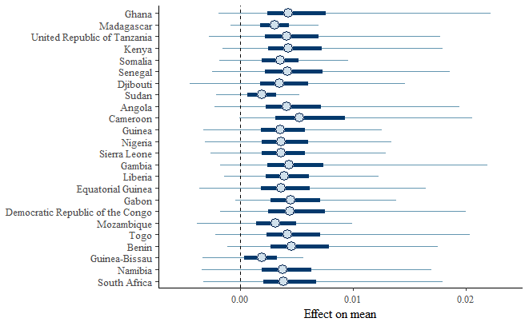

```r
plot(baggr_africa, order = FALSE)
```

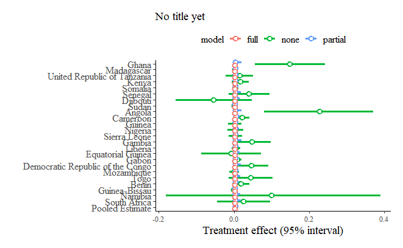

```r
my_baggr_comparison <- baggr_compare(subset_data)
plot(my_baggr_comparison) +
  ggtitle("No title yet")
```

## Ethnicities

Match country name based on its cities location.

```r
temp_df <- dist_df %>%
  filter(!city_id %in% c(22453, 22451, 22452, 22450)) %>%
  mutate(geom = st_centroid(geom))

# Reproject the 'dist_sf' geometry
city_point <- st_transform(temp_df, st_crs(etno_df$geometry))

# Convert 'city_point' to an sf object
city_point_sf <- st_sf(geometry = city_point)

# Perform the spatial join to add country names
matched <- st_join(city_point_sf, etno_df["group"])
```

That’s it so far.